# **Examining Jail Death Rates From 2010 - 2019**

Tutorial by Priyanka Mehta and Grace Stewart

## **Introduction**

Throughout this tutorial, we will be guiding you through the Data Science pipeline, which includes the following phases:

1. Data collection/curation + parsing
2. Data management/representation
3. Exploratory data analysis
4. Hypothesis testing and machine learning
5. Communication of insights attained

Although listed in number order, you will noticed that the Data Science pipeline is not linear. Not only does it allow for you to return to previous steps, but this kind of cycle is encouraged as you discover more information about your data. For this tutorial, we will be focusing on examining jail death rates from 2010 to 2019.

## **Data Download**

Before we can examine jail death rates, we must first collect the desired data. Originally from the websites linked at [0] and [1], we downloaded two files: one containing jail death information for all federal jails in the United States of America, and one containing population information per state. You will see that both of these sets of data will come in handy later.

[0] https://www.reuters.com/investigates/special-report/usa-jails-graphic/

[1] https://www.census.gov/data/tables/time-series/demo/popest/2010s-state-total.html

```python
!wget https://graphics.thomsonreuters.com/data/jails/Allstatesinsurvey.zip
!wget http://www2.census.gov/programs-surveys/popest/datasets/2010-2019/national/totals/nst-est2019-alldata.csv
```

```
A
--2021-05-16 20:41:30--  https://graphics.thomsonreuters.com/data/jails/Allstatesinsurvey.zip
Resolving graphics.thomsonreuters.com (graphics.thomsonreuters.com)... y
13.225.149.12, 13.225.149.27, 13.225.149.61, ...
Connecting to graphics.thomsonreuters.com (graphics.thomsonreuters.com)|13.225.149.12|:443... connected.
HTTP request sent, awaiting response... 200 OK
Length: 287523 (281K) [application/zip]
Saving to: ‘Allstatesinsurvey.zip.2’

Allstatesinsurvey.z 100%[===================>] 280.78K  --.-KB/s    in 0.03s

2021-05-16 20:41:30 (10.3 MB/s) - ‘Allstatesinsurvey.zip.2’ saved [287523/287523]

URL transformed to HTTPS due to an HSTS policy
--2021-05-16 20:41:30--  https://www2.census.gov/programs-surveys/popest/datasets/2010-2019/national/totals/nst-est2019-alldata.csv
Resolving www2.census.gov (www2.census.gov)... 23.14.164.64, 2600:1406:c800:39a::208c, 2600:1406:c800:383::208c
Connecting to www2.census.gov (www2.census.gov)|23.14.164.64|:443... connected.
HTTP request sent, awaiting response... 200 OK
Length: unspecified [text/csv]
Saving to: ‘nst-est2019-alldata.csv.2’

nst-est2019-alldata     [ <=>                ]  72.35K  --.-KB/s    in 0.07s

2021-05-16 20:41:31 (998 KB/s) - ‘nst-est2019-alldata.csv.2’ saved [74085]
```

```python
!unzip Allstatesinsurvey.zip
```

```
Archive:  Allstatesinsurvey.zip
replace all_deaths.csv? [y]es, [n]o, [A]ll, [N]one, [r]ename: A
  inflating: all_deaths.csv
  inflating: all_jails.csv
  inflating: reuters-jail-deaths-codesheets.xlsx
```

## **Package Imports and Data Management**

Now that we have access to all of the desired data from the files in the previous step, we need to store the data in a more manageable way. One excellent way of storing that data is in a pandas dataframe [2], which is how we choose to store the data from the CSV files as well. This will allow us to access, view, and manipulate the desired data with ease.

[2] https://www.geeksforgeeks.org/python-pandas-dataframe/

```python
import pandas as pd

death_table = pd.read_csv("./all_deaths.csv", engine='python')
jail_table = pd.read_csv("./all_jails.csv", engine='python')
population_table = pd.read_csv("./nst-est2019-alldata.csv", engine='python')
```

### **Display All Dataframes**

A great way to get a better look at your data and to verify that you collected what you need is to take a quick look at your dataframes. By calling head(), you will get to see the first 5 rows of your dataframe. Here you can see that we have created three different tables: one containing the total deaths per year per jail, one containing information about each death individually, and one containing population information per state.

```python
jail_table.head()
```

|  | id | fips | statecode | state | state_notes | county | jail | jail_notes | d2008 | d2009 | d2010 | d2011 | d2012 | d2013 | d2014 | d2015 | d2016 | d2017 | d2018 | d2019 | su2008 | su2009 | su2010 | su2011 | su2012 | su2013 | su2014 | su2015 | su2016 | … |
| --- | --- | --- | --- | --- | --- | --- | --- | --- | --- | --- | --- | --- | --- | --- | --- | --- | --- | --- | --- | --- | --- | --- | --- | --- | --- | --- | --- | --- | --- | --- |
| 0 | 1 | 1003.0 | AL | Alabama | NaN | Baldwin | Baldwin County Corr. Center | NaN | 0.0 | 0.0 | 1.0 | 1.0 | 0.0 | 0.0 | 0.0 | 2.0 | 0.0 | 0.0 | 2.0 | 0.0 | 0.0 | 0.0 | 0.0 | 1.0 | 0.0 | 0.0 | 0.0 | 0.0 | 0.0 | … |
| 1 | 2 | 1015.0 | AL | Alabama | NaN | Calhoun | Calhoun County Jail | NaN | 0.0 | 1.0 | 1.0 | 0.0 | 0.0 | 1.0 | 0.0 | 1.0 | 0.0 | 0.0 | 1.0 | 0.0 | 0.0 | 0.0 | 0.0 | 0.0 | 0.0 | 0.0 | 0.0 | 1.0 | 0.0 | … |
| 2 | 3 | 1055.0 | AL | Alabama | NaN | Etowah | Etowah County Detention Center | NaN | 0.0 | 0.0 | 0.0 | 2.0 | 0.0 | 1.0 | 0.0 | 0.0 | 2.0 | 1.0 | 0.0 | NaN | 0.0 | 0.0 | 0.0 | 0.0 | 0.0 | 0.0 | 0.0 | 0.0 | 0.0 | … |
| 3 | 4 | 1069.0 | AL | Alabama | NaN | Houston | Houston County Jail | NaN | 1.0 | 0.0 | 0.0 | 0.0 | 1.0 | 0.0 | 0.0 | 1.0 | 2.0 | 0.0 | 0.0 | 1.0 | 0.0 | 0.0 | 0.0 | 0.0 | 0.0 | 0.0 | 0.0 | 1.0 | 0.0 | … |
| 4 | 5 | 1073.0 | AL | Alabama | NaN | Jefferson | Jefferson County Birmingham Jail | ADP for 2008 was based on data provided by the... | NaN | NaN | NaN | NaN | NaN | 1.0 | 2.0 | 0.0 | 0.0 | 0.0 | 2.0 | 5.0 | NaN | NaN | NaN | NaN | NaN | 0.0 | 0.0 | 0.0 | 0.0 | … |

5 rows × 116 columns

```python
death_table.head()
```

|  | id | state | county | jail | year | date_of_death | full_name | last_name | first_name | mid_name | suffix | date_incarcerated | cause_short | cause_detail | dob | yob | age | race | race_detail | gender | custody_status | what_info_from_media |
| --- | --- | --- | --- | --- | --- | --- | --- | --- | --- | --- | --- | --- | --- | --- | --- | --- | --- | --- | --- | --- | --- | --- |
| 0 | 1.0 | AL | Baldwin | Baldwin County Corr. Center | 2010 | NaN | NaN | NaN | NaN | NaN | NaN | NaN | M | NaN | NaN | NaN | NaN | NaN | NaN | NaN | NaN | NaN |
| 1 | 1.0 | AL | Baldwin | Baldwin County Corr. Center | 2011 | NaN | NaN | NaN | NaN | NaN | NaN | NaN | S | NaN | NaN | NaN | NaN | NaN | NaN | NaN | NaN | NaN |
| 2 | 1.0 | AL | Baldwin | Baldwin County Corr. Center | 2015 | NaN | NaN | NaN | NaN | NaN | NaN | NaN | DA | NaN | NaN | NaN | NaN | NaN | NaN | NaN | NaN | NaN |
| 3 | 1.0 | AL | Baldwin | Baldwin County Corr. Center | 2015 | NaN | NaN | NaN | NaN | NaN | NaN | NaN | M | NaN | NaN | NaN | NaN | NaN | NaN | NaN | NaN | NaN |
| 4 | 1.0 | AL | Baldwin | Baldwin County Corr. Center | 2018 | NaN | NaN | NaN | NaN | NaN | NaN | NaN | M | Acute Bronchopneumonia | NaN | NaN | NaN | NaN | NaN | NaN | NaN | NaN |

```python
population_table.head()
```

|  | SUMLEV | REGION | DIVISION | STATE | NAME | CENSUS2010POP | ESTIMATESBASE2010 | POPESTIMATE2010 | POPESTIMATE2011 | POPESTIMATE2012 | POPESTIMATE2013 | POPESTIMATE2014 | POPESTIMATE2015 | POPESTIMATE2016 | POPESTIMATE2017 | POPESTIMATE2018 | POPESTIMATE2019 | NPOPCHG_2010 | NPOPCHG_2011 | NPOPCHG_2012 | NPOPCHG_2013 | NPOPCHG_2014 | NPOPCHG_2015 | NPOPCHG_2016 | NPOPCHG_2017 | NPOPCHG_2018 | NPOPCHG_2019 | BIRTHS2010 | BIRTHS2011 | … |
| --- | --- | --- | --- | --- | --- | --- | --- | --- | --- | --- | --- | --- | --- | --- | --- | --- | --- | --- | --- | --- | --- | --- | --- | --- | --- | --- | --- | --- | --- | --- |
| 0 | 10 | 0 | 0 | 0 | United States | 308745538 | 308758105 | 309321666 | 311556874 | 313830990 | 315993715 | 318301008 | 320635163 | 322941311 | 324985539 | 326687501 | 328239523 | 563561 | 2235208 | 2274116 | 2162725 | 2307293 | 2334155 | 2306148 | 2044228 | 1701962 | 1552022 | 987836 | 3973485 | … |
| 1 | 20 | 1 | 0 | 0 | Northeast Region | 55317240 | 55318443 | 55380134 | 55604223 | 55775216 | 55901806 | 56006011 | 56034684 | 56042330 | 56059240 | 56046620 | 55982803 | 61691 | 224089 | 170993 | 126590 | 104205 | 28673 | 7646 | 16910 | -12620 | -63817 | 163466 | 646249 | … |
| 2 | 20 | 2 | 0 | 0 | Midwest Region | 66927001 | 66929725 | 66974416 | 67157800 | 67336743 | 67560379 | 67745167 | 67860583 | 67987540 | 68126781 | 68236628 | 68329004 | 44691 | 183384 | 178943 | 223636 | 184788 | 115416 | 126957 | 139241 | 109847 | 92376 | 212570 | 834866 | … |
| 3 | 20 | 3 | 0 | 0 | South Region | 114555744 | 114563030 | 114866680 | 116006522 | 117241208 | 118364400 | 119624037 | 120997341 | 122351760 | 123542189 | 124569433 | 125580448 | 303650 | 1139842 | 1234686 | 1123192 | 1259637 | 1373304 | 1354419 | 1190429 | 1027244 | 1011015 | 368759 | 1509634 | … |
| 4 | 20 | 4 | 0 | 0 | West Region | 71945553 | 71946907 | 72100436 | 72788329 | 73477823 | 74167130 | 74925793 | 75742555 | 76559681 | 77257329 | 77834820 | 78347268 | 153529 | 687893 | 689494 | 689307 | 758663 | 816762 | 817126 | 697648 | 577491 | 512448 | 243041 | 982736 | … |

5 rows × 151 columns

### **Note:**

After taking a good look at our data, we realized that the data in death_table is incredibly limited, and all information that we need is jail_table and population_table. As a result, we neither use nor reference death_table in the rest of this tutorial. A big part of data science is deciding what data you need to accomplish your task, and what may not be needed at the moment.

## **Tidy Data**

Once we have the appropriate data loaded, the next step is to understand what parts are most relevant for our purposes, since not all of the data will be useful and can actually slow down our analysis. To understand what data we need, we can cross-reference the dataframe with the information provided on the website the data originates from to learn what all of the different columns mean.

In the jail table, we are able to extrapolate what the following abbreviations mean: d = total deaths, su = suicides, da = drugs/alcohol, il = illness, ho = homicides, ac = accidents, adp = average daily inmates. This allows us to trim all of the columns except for the total inmate deaths by location, which is what we are really interested in.

```python
jail_table.drop(['state_notes', 'jail_notes', 'id'], axis=1, inplace=True)
jail_table = jail_table[jail_table.columns.drop(list(jail_table.filter(regex='med')))]
jail_table = jail_table.loc[:, :'d2019']
jail_table.head()
```

|  | fips | statecode | state | county | jail | d2008 | d2009 | d2010 | d2011 | d2012 | d2013 | d2014 | d2015 | d2016 | d2017 | d2018 | d2019 |
| --- | --- | --- | --- | --- | --- | --- | --- | --- | --- | --- | --- | --- | --- | --- | --- | --- | --- |
| 0 | 1003.0 | AL | Alabama | Baldwin | Baldwin County Corr. Center | 0.0 | 0.0 | 1.0 | 1.0 | 0.0 | 0.0 | 0.0 | 2.0 | 0.0 | 0.0 | 2.0 | 0.0 |
| 1 | 1015.0 | AL | Alabama | Calhoun | Calhoun County Jail | 0.0 | 1.0 | 1.0 | 0.0 | 0.0 | 1.0 | 0.0 | 1.0 | 0.0 | 0.0 | 1.0 | 0.0 |
| 2 | 1055.0 | AL | Alabama | Etowah | Etowah County Detention Center | 0.0 | 0.0 | 0.0 | 2.0 | 0.0 | 1.0 | 0.0 | 0.0 | 2.0 | 1.0 | 0.0 | NaN |
| 3 | 1069.0 | AL | Alabama | Houston | Houston County Jail | 1.0 | 0.0 | 0.0 | 0.0 | 1.0 | 0.0 | 0.0 | 1.0 | 2.0 | 0.0 | 0.0 | 1.0 |
| 4 | 1073.0 | AL | Alabama | Jefferson | Jefferson County Birmingham Jail | NaN | NaN | NaN | NaN | NaN | 1.0 | 2.0 | 0.0 | 0.0 | 0.0 | 2.0 | 5.0 |

We repeat these steps for the table holding US Census data, since we aren't specifically interested in the immigration and birth/death data, but rather the total population estimates by state.

```python
population_estimates = population_table.loc[:, :'POPESTIMATE2019']
population_estimates = population_estimates.loc[:, 'NAME':]
population_estimates = population_estimates.iloc[5:]
population_estimates.head()
```

|  | NAME | CENSUS2010POP | ESTIMATESBASE2010 | POPESTIMATE2010 | POPESTIMATE2011 | POPESTIMATE2012 | POPESTIMATE2013 | POPESTIMATE2014 | POPESTIMATE2015 | POPESTIMATE2016 | POPESTIMATE2017 | POPESTIMATE2018 | POPESTIMATE2019 |
| --- | --- | --- | --- | --- | --- | --- | --- | --- | --- | --- | --- | --- | --- |
| 5 | Alabama | 4779736 | 4780125 | 4785437 | 4799069 | 4815588 | 4830081 | 4841799 | 4852347 | 4863525 | 4874486 | 4887681 | 4903185 |
| 6 | Alaska | 710231 | 710249 | 713910 | 722128 | 730443 | 737068 | 736283 | 737498 | 741456 | 739700 | 735139 | 731545 |
| 7 | Arizona | 6392017 | 6392288 | 6407172 | 6472643 | 6554978 | 6632764 | 6730413 | 6829676 | 6941072 | 7044008 | 7158024 | 7278717 |
| 8 | Arkansas | 2915918 | 2916031 | 2921964 | 2940667 | 2952164 | 2959400 | 2967392 | 2978048 | 2989918 | 3001345 | 3009733 | 3017804 |
| 9 | California | 37253956 | 37254519 | 37319502 | 37638369 | 37948800 | 38260787 | 38596972 | 38918045 | 39167117 | 39358497 | 39461588 | 39512223 |

## **Create Cumulative Table by State and Add Regions**

Note that the population and jail data tables are currently in different formats; namely, the jail data is distributed by county while the census data is by state. To fix this, we can use the groupby function and aggregate all of the values for counties of a particular state, which will create rows that are now sorted only by state.

```python
state_table = jail_table.groupby(["statecode"], as_index=False).agg('sum')
state_table.head()
```

|  | statecode | fips | d2008 | d2009 | d2010 | d2011 | d2012 | d2013 | d2014 | d2015 | d2016 | d2017 | d2018 | d2019 |
| --- | --- | --- | --- | --- | --- | --- | --- | --- | --- | --- | --- | --- | --- | --- |
| 0 | AL | 14023.0 | 4.0 | 4.0 | 3.0 | 6.0 | 4.0 | 10.0 | 4.0 | 7.0 | 8.0 | 5.0 | 8.0 | 17.0 |
| 1 | AR | 50816.0 | 3.0 | 3.0 | 4.0 | 5.0 | 8.0 | 9.0 | 12.0 | 7.0 | 4.0 | 4.0 | 8.0 | 4.0 |
| 2 | AZ | 44175.0 | 11.0 | 9.0 | 13.0 | 5.0 | 6.0 | 14.0 | 18.0 | 25.0 | 22.0 | 28.0 | 26.0 | 18.0 |
| 3 | CA | 230270.0 | 85.0 | 112.0 | 95.0 | 73.0 | 93.0 | 104.0 | 116.0 | 110.0 | 98.0 | 106.0 | 103.0 | 126.0 |
| 4 | CO | 80520.0 | 11.0 | 11.0 | 18.0 | 10.0 | 8.0 | 13.0 | 12.0 | 23.0 | 19.0 | 26.0 | 13.0 | 21.0 |

It is always a good idea to take a closer look at your data and make sure that you don't have missing information. For example, after further examination of the statecodes below, it becomes clear that there are some states missing from the list: Alaska, Connecticut, Delaware, Hawaii, Rhode Island, and Vermont.

Upon external research [3], we can see that this is due to the fact that these states do not have any federal prisons, with the exception of Connecticut, which has one. This is a reasonable explanation for why these states may not have any data available.

[3] https://en.wikipedia.org/wiki/List_of_United_States_federal_prisons

```python
state_table["statecode"].values
```

```
array(['AL', 'AR', 'AZ', 'CA', 'CO', 'DC', 'FL', 'GA', 'IA', 'ID', 'IL',
       'IN', 'KS', 'KY', 'LA', 'MA', 'MD', 'ME', 'MI', 'MN', 'MO', 'MS',
       'MT', 'NC', 'ND', 'NE', 'NH', 'NJ', 'NM', 'NV', 'NY', 'OH', 'OK',
       'OR', 'PA', 'SC', 'SD', 'TN', 'TX', 'UT', 'VA', 'WA', 'WI', 'WV',
       'WY'], dtype=object)
```

Next, create some lookup tables that will help us format our data better. Since we are specifically interested in jail deaths by US Region, one of our dictionaries helps map each state to its respective region, which we can then use to perform our analysis. The other table simply converts state names to their abbreviations, since the US Census data utilizes only names, but our formatting of the prison data uses abbreviations.

```python
US_regions = {"Pacific": ["WA", "OR", "CA"],
              "Rocky Mountain": ["MT", "NV", "ID", "WY", "UT", "CO"],
              "Southwest": ["AZ", "NM", "OK", "TX"],
              "Midwest": ["ND", "SD", "NE", "KS", "MN", "IA", "MO", "WI", "IL", "IN", "MI", "OH"],
              "Southeast": ["AR", "LA", "MS", "AL", "GA", "FL", "SC", "TN", "KY", "NC", "VA", "WV"],
              "Northeast": ["MD", "DE", "NJ", "PA", "NY", "MA", "NH", "VT", "CT", "ME", "RI"]}
```

```python
state_abbrev = {'Alabama': 'AL','Alaska': 'AK','American Samoa': 'AS','Arizona': 'AZ','Arkansas': 'AR','California': 'CA','Colorado': 'CO','Connecticut': 'CT','Delaware': 'DE','District of Columbia': 'DC','Florida': 'FL','Georgia': 'GA','Guam': 'GU','Hawaii': 'HI','Idaho': 'ID','Illinois': 'IL','Indiana': 'IN','Iowa': 'IA','Kansas': 'KS','Kentucky': 'KY','Louisiana': 'LA','Maine': 'ME','Maryland': 'MD','Massachusetts': 'MA','Michigan': 'MI','Minnesota': 'MN','Mississippi': 'MS','Missouri': 'MO','Montana': 'MT','Nebraska': 'NE','Nevada': 'NV','New Hampshire': 'NH','New Jersey': 'NJ','New Mexico': 'NM','New York': 'NY','North Carolina': 'NC','North Dakota': 'ND','Northern Mariana Islands':'MP','Ohio': 'OH','Oklahoma': 'OK','Oregon': 'OR','Pennsylvania': 'PA','Puerto Rico': 'PR','Rhode Island': 'RI','South Carolina': 'SC','South Dakota': 'SD','Tennessee': 'TN','Texas': 'TX','Utah': 'UT','Vermont': 'VT','Virgin Islands': 'VI','Virginia': 'VA','Washington': 'WA','West Virginia': 'WV','Wisconsin': 'WI','Wyoming': 'WY'}
```

Once we have the lookup tables, we can use them to add a region column to our datasets. Below are the two tables for jail and population data sorted by state with the region values included.

```python
# Iterate through state prison data and add regions accordingly
for i,r in state_table.iterrows():
    for k,v in US_regions.items():
        if r["statecode"] in v:
            reg = k
            break
    state_table.loc[i, "region"] = reg
state_table.head()
```

|  | statecode | fips | d2008 | d2009 | d2010 | d2011 | d2012 | d2013 | d2014 | d2015 | d2016 | d2017 | d2018 | d2019 | region |
| --- | --- | --- | --- | --- | --- | --- | --- | --- | --- | --- | --- | --- | --- | --- | --- |
| 0 | AL | 14023.0 | 4.0 | 4.0 | 3.0 | 6.0 | 4.0 | 10.0 | 4.0 | 7.0 | 8.0 | 5.0 | 8.0 | 17.0 | Southeast |
| 1 | AR | 50816.0 | 3.0 | 3.0 | 4.0 | 5.0 | 8.0 | 9.0 | 12.0 | 7.0 | 4.0 | 4.0 | 8.0 | 4.0 | Southeast |
| 2 | AZ | 44175.0 | 11.0 | 9.0 | 13.0 | 5.0 | 6.0 | 14.0 | 18.0 | 25.0 | 22.0 | 28.0 | 26.0 | 18.0 | Southwest |
| 3 | CA | 230270.0 | 85.0 | 112.0 | 95.0 | 73.0 | 93.0 | 104.0 | 116.0 | 110.0 | 98.0 | 106.0 | 103.0 | 126.0 | Pacific |
| 4 | CO | 80520.0 | 11.0 | 11.0 | 18.0 | 10.0 | 8.0 | 13.0 | 12.0 | 23.0 | 19.0 | 26.0 | 13.0 | 21.0 | Rocky Mountain |

```python
# Iterate through state population data and add regions accordingly
for i,r in population_estimates.iterrows():
    state = r["NAME"]
    if state in state_abbrev:
        abb = state_abbrev[state]
        for k,v in US_regions.items():
            if abb in v:
                reg = k
                break
    population_estimates.loc[i, "region"] = reg
population_estimates.head()
```

|  | NAME | CENSUS2010POP | ESTIMATESBASE2010 | POPESTIMATE2010 | POPESTIMATE2011 | POPESTIMATE2012 | POPESTIMATE2013 | POPESTIMATE2014 | POPESTIMATE2015 | POPESTIMATE2016 | POPESTIMATE2017 | POPESTIMATE2018 | POPESTIMATE2019 | region |
| --- | --- | --- | --- | --- | --- | --- | --- | --- | --- | --- | --- | --- | --- | --- |
| 5 | Alabama | 4779736 | 4780125 | 4785437 | 4799069 | 4815588 | 4830081 | 4841799 | 4852347 | 4863525 | 4874486 | 4887681 | 4903185 | Southeast |
| 6 | Alaska | 710231 | 710249 | 713910 | 722128 | 730443 | 737068 | 736283 | 737498 | 741456 | 739700 | 735139 | 731545 | Southeast |
| 7 | Arizona | 6392017 | 6392288 | 6407172 | 6472643 | 6554978 | 6632764 | 6730413 | 6829676 | 6941072 | 7044008 | 7158024 | 7278717 | Southwest |
| 8 | Arkansas | 2915918 | 2916031 | 2921964 | 2940667 | 2952164 | 2959400 | 2967392 | 2978048 | 2989918 | 3001345 | 3009733 | 3017804 | Southeast |
| 9 | California | 37253956 | 37254519 | 37319502 | 37638369 | 37948800 | 38260787 | 38596972 | 38918045 | 39167117 | 39358497 | 39461588 | 39512223 | Pacific |

## **Create Dictionaries for Clean Data Storage**

As mentioned previously, because we are looking at jail death rate per region, we created a Python dictionary of dictionaries. This will map a list of total jail deaths per year to their respective states, then each state to it's respective region of the United States. This method of storage will allow for easy access to the data, as well as a simple way of keeping which states / death rates belong to which region clear.

```python
state_totals = {'Pacific':{}, 'Rocky Mountain':{}, 'Southeast':{}, 'Southwest':{}, 'Midwest':{}, 'Northeast':{}}

for i,r in state_table.iterrows():
    state_totals[r['region']][r['statecode']] = [r['d2010'], r['d2011'],r['d2012'],r['d2013'],r['d2014'],r['d2015'],r['d2016'],r['d2017'],r['d2018'],r['d2019']]
```

Although the breakdown of jail death rates per state per region is handy to have, and will be important later, we first want to look at just the total number of jail deaths per year per region. By starting off very broadly, and looking at our data wholistically, we can simply explore the data, and check for any trends or noticeable features. In order to do this, we created a dictionary mapping a list of total deaths per year to its respective region.

```python
from operator import add

region_totals = {'Pacific':[], 'Rocky Mountain':[], 'Southeast':[], 'Southwest':[], 'Midwest':[], 'Northeast':[]}

# Iterate through all of the state prison counts
for key in state_totals.keys():
    states = state_totals[key]
    death_list = [0]*10
    # For each year, copy the values to region counts
    for k in states.keys():
        death_list = list(map(add, death_list, states[k]))
    region_totals[key] = death_list
```

## **Exploratory Data Analysis**

At this point, while we have our data stored in mangable ways (dictionaries), we don't actually know anything about trends, outliers, or any other noticeable features (if there are any - it could be all totally random!). To start learning about the data, we first want to just start exploring it. We picked a starting point, jail deaths per year per region, that is incredibly broad in order for us to get an initial feel for the data. From this initial plot we can then determine where we can go next with the data, what to look at next, or if this was a bad starting point and to just try again (which is totally okay! If this happens, just pick a new starting point, maybe redo how you store your data, and try again!).

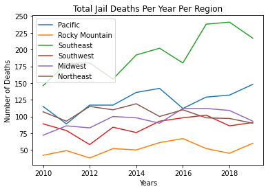

```python
import matplotlib.pyplot as plt

# Plot regions totals over years
years = [2010, 2011, 2012, 2013, 2014, 2015, 2016, 2017, 2018, 2019]
for key in region_totals.keys():
    plt.plot(years, region_totals[key],label=key)
    plt.legend()

plt.title("Total Jail Deaths Per Year Per Region")
plt.ylabel("Number of Deaths")
plt.xlabel("Years");
```

### **Looking Closer at Outliers / Interesting Trends**

Looking at the graph above, instantly two things jump out: (1) that the number of jail deaths per year in the Southeast are consistently quite a bit higher than in other regions, and increases quite a bit over the years, and (2) that the number of jail deaths per year seems to decrease over the years in the Northeast. Because a big part of Data Science is exploring your data and taking a closer look into interesting observations. Because of this, we decided to plot a scatter plot of total jail deaths per year per region, and utilize linear regression to create a line of best fit per region.

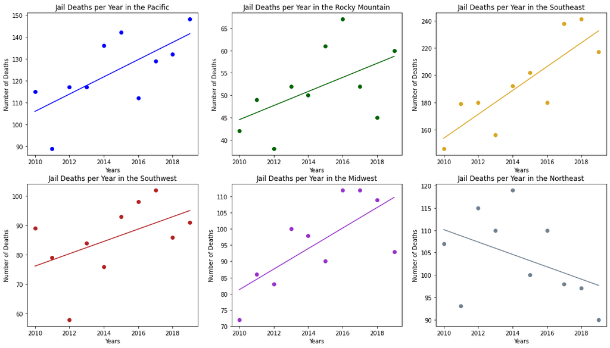

```python
from numpy.polynomial.polynomial import polyfit
import numpy as np

fig, axs = plt.subplots(2, 3, figsize=(18,10))
colors = ['blue', 'darkgreen', 'goldenrod', 'firebrick', 'darkorchid', 'slategrey']
i = 0

for key in region_totals.keys():
    # Plot region jail death totals
    axs[i//3, i%3].scatter(years, region_totals[key], color=colors[i])
    b, m = polyfit(years, region_totals[key], 1)
    axs[i//3, i%3].plot(years, b + m * np.array(years), '-', c=colors[i])
    axs[i//3, i%3].set_title("Jail Deaths per Year in the "+ key)
    axs[i//3, i%3].set_ylabel("Number of Deaths")
    axs[i//3, i%3].set_xlabel("Years")
    i += 1

plt.show()
```

## **But Wait - What About External Factors?**

The graphs above are a great start, but we forgot to think about a pretty major factor... what about population? Although there are many, many other factors that likely affect this data as well, one major factor is the population in each state, and thus the population in each region. It is safe to assume that areas with a higher populations will have either more or larger jails, and thus would have more jail deaths in total, but maybe not more jail deaths per capita. Because of this, we normalize our region jail death data by total region population, and redo the process above with our normalized data.

```python
state_pop_totals = {'Pacific':{}, 'Rocky Mountain':{}, 'Southeast':{}, 'Southwest':{}, 'Midwest':{}, 'Northeast':{}}

# Tally total counts for state populations
for i,r in population_estimates.iterrows():
    state_pop_totals[r['region']][state_abbrev[r['NAME']]] = [r['POPESTIMATE2010'], r['POPESTIMATE2011'], r['POPESTIMATE2012'], r['POPESTIMATE2013'],r['POPESTIMATE2014'],r['POPESTIMATE2015'],r['POPESTIMATE2016'],r['POPESTIMATE2017'],r['POPESTIMATE2018'],r['POPESTIMATE2019']]
```

```python
region_pop_totals = {'Pacific':[], 'Rocky Mountain':[], 'Southeast':[], 'Southwest':[], 'Midwest':[], 'Northeast':[]}

# Iterate through all states and calculate population totals by region
for key in state_pop_totals.keys():
    states = state_pop_totals[key]
    death_list = [0]*12
    for k in states.keys():
        death_list = list(map(add, death_list, states[k]))
    region_pop_totals[key] = death_list
```

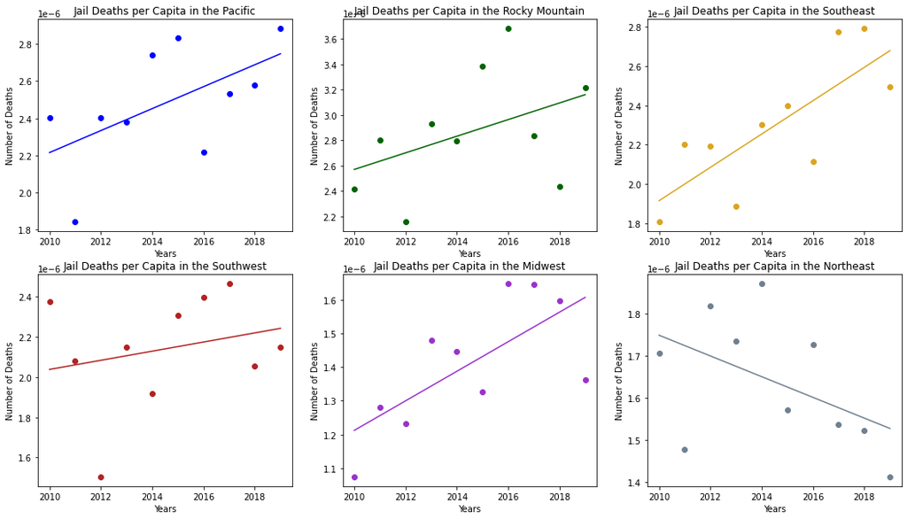

```python
from operator import truediv

fig, axs = plt.subplots(2, 3, figsize=(18,10))
colors = ['blue', 'darkgreen', 'goldenrod', 'firebrick', 'darkorchid', 'slategrey']
i = 0

for key in region_totals.keys():
    # Plot region jail death totals over region population counts
    axs[i//3, i%3].scatter(years, list(map(truediv, region_totals[key], region_pop_totals[key])), color=colors[i])
    b, m = polyfit(years, list(map(truediv, region_totals[key], region_pop_totals[key])), 1)
    axs[i//3, i%3].plot(years, b + m * np.array(years), '-', c=colors[i])
    axs[i//3, i%3].set_title("Jail Deaths per Capita in the "+ key)
    axs[i//3, i%3].set_ylabel("Number of Deaths")
    axs[i//3, i%3].set_xlabel("Years")
    i += 1

plt.show()
```

## **Examining Outliers (Again!)**

Now that we've accounted for at least one major factor, we can see that the previous observations about the Southeast and Northeast still stand. Because of this, we decided to take a closer look at these two regions in order to see if certain states are swaying the data, or if any other interesting observations make themselves apparent.

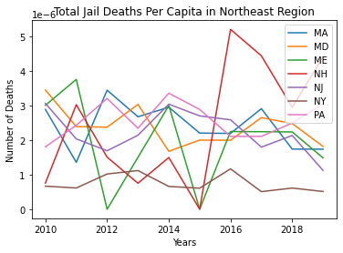

```python
northeast_jail_dict = state_totals['Northeast']
northeast_pop_dict = state_pop_totals['Northeast']

# Graph Northeast specifically
for key in northeast_jail_dict.keys():
    plt.plot(years, list(map(truediv, northeast_jail_dict[key], northeast_pop_dict[key])), label=key)
    plt.legend()
plt.title("Total Jail Deaths Per Capita in Northeast Region")
plt.ylabel("Number of Deaths")
plt.xlabel("Years");
plt.show()
```

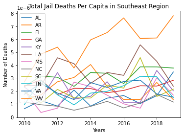

```python
southeast_jail_dict = state_totals['Southeast']
southeast_pop_dict = state_pop_totals['Southeast']

# Graph Southeast specifically
for key in southeast_jail_dict.keys():
    plt.plot(years, list(map(truediv, southeast_jail_dict[key], southeast_pop_dict[key])), label=key)
    plt.legend()
plt.title("Total Jail Deaths Per Capita in Southeast Region")
plt.ylabel("Number of Deaths")
plt.xlabel("Years");
```

## **Linear Regression**

Below, we perform linear regression on the Southeast region to examine if one state is affecting the general trend more than others. To do so, we use an interaction [4], which is essentially an analysis of the different states in the region and how they affect the general trend. Then, we can see if the effect of one particular state is statistically significant.

We begin by constructing a dataframe specifically for the data from the Southeast region and then modifying the data so that the different years are in rows of their own instead of columns. Then, we create the interaction by creating rows of binary values, and run our linear regression analyses on these rows.

[4] https://stattrek.com/multiple-regression/interaction.aspx

```python
# Extract Southeast data only and drop the two years that we don't have population data for
southeast_table = state_table.loc[state_table['region'] == "Southeast"]
southeast_table = southeast_table.drop(["d2008","d2009","region"], axis=1)
southeast_table.head()
```

|  | statecode | fips | d2010 | d2011 | d2012 | d2013 | d2014 | d2015 | d2016 | d2017 | d2018 | d2019 |
| --- | --- | --- | --- | --- | --- | --- | --- | --- | --- | --- | --- | --- |
| 0 | AL | 14023.0 | 3.0 | 6.0 | 4.0 | 10.0 | 4.0 | 7.0 | 8.0 | 5.0 | 8.0 | 17.0 |
| 1 | AR | 50816.0 | 4.0 | 5.0 | 8.0 | 9.0 | 12.0 | 7.0 | 4.0 | 4.0 | 8.0 | 4.0 |
| 6 | FL | 277728.0 | 44.0 | 60.0 | 59.0 | 46.0 | 68.0 | 68.0 | 53.0 | 81.0 | 82.0 | 81.0 |
| 7 | GA | 170583.0 | 23.0 | 28.0 | 17.0 | 22.0 | 22.0 | 19.0 | 21.0 | 25.0 | 25.0 | 30.0 |
| 13 | KY | 274119.0 | 10.0 | 6.0 | 15.0 | 6.0 | 7.0 | 12.0 | 5.0 | 5.0 | 16.0 | 9.0 |

```python
# For each year of data that we have, calculate average inmate deaths per capita
adj_cols = ["2010","2011","2012","2013","2014","2015","2016","2017","2018","2019"]

# Need to rename the year columns for them to match up
southeast_table.columns = southeast_table.columns.str.replace("[d]", "")
southeast_table.rename(columns={'statecoe':'statecode'}, inplace=True)

for i,r in southeast_table.iterrows():
    s = r["statecode"]
    for j in range(len(adj_cols)):
        # Calculate the averages per year
        southeast_table.loc[i, adj_cols[j]] = r[adj_cols[j]] / southeast_pop_dict[s][j]
```

```python
# Adjust the table using melt() to transform the years to rows instead of columns
southeast_table = southeast_table.melt(id_vars=["statecode", "fips"], var_name="year", value_name="death_rate")
southeast_table["year"] = pd.to_numeric(southeast_table["year"])

# Convert the columns to hold binary values
features = pd.get_dummies(southeast_table.statecode, drop_first=True, prefix='statecode')
standard_features = southeast_table[['year', 'death_rate']]
combined_features = pd.concat([standard_features, features], axis=1)
```

```python
# Need to manually remove some states for which there was no data
states = list(southeast_pop_dict.keys())
states.remove("AK")
states.remove("HI")

# Create the combines table
for c in filter(lambda c: c !="AL", states):
    combined_features["year*"+c] = combined_features["statecode_"+c]*combined_features["year"]

combined_features.head()
```

|  | year | death_rate | statecode_AR | statecode_FL | statecode_GA | statecode_KY | statecode_LA | statecode_MS | statecode_NC | statecode_SC | statecode_TN | statecode_VA | statecode_WV | year*AR | year*FL | year*GA | year*KY | year*LA | year*MS | year*NC | year*SC | year*TN | year*VA | year*WV |
| --- | --- | --- | --- | --- | --- | --- | --- | --- | --- | --- | --- | --- | --- | --- | --- | --- | --- | --- | --- | --- | --- | --- | --- | --- |
| 0 | 2010 | 1.310020e-13 | 0 | 0 | 0 | 0 | 0 | 0 | 0 | 0 | 0 | 0 | 0 | 0 | 0 | 0 | 0 | 0 | 0 | 0 | 0 | 0 | 0 | 0 |
| 1 | 2010 | 4.685007e-13 | 1 | 0 | 0 | 0 | 0 | 0 | 0 | 0 | 0 | 0 | 0 | 2010 | 0 | 0 | 0 | 0 | 0 | 0 | 0 | 0 | 0 | 0 |
| 2 | 2010 | 1.238898e-13 | 0 | 1 | 0 | 0 | 0 | 0 | 0 | 0 | 0 | 0 | 0 | 0 | 2010 | 0 | 0 | 0 | 0 | 0 | 0 | 0 | 0 | 0 |
| 3 | 2010 | 2.438491e-13 | 0 | 0 | 1 | 0 | 0 | 0 | 0 | 0 | 0 | 0 | 0 | 0 | 0 | 2010 | 0 | 0 | 0 | 0 | 0 | 0 | 0 | 0 |
| 4 | 2010 | 5.289136e-13 | 0 | 0 | 0 | 1 | 0 | 0 | 0 | 0 | 0 | 0 | 0 | 0 | 0 | 0 | 2010 | 0 | 0 | 0 | 0 | 0 | 0 | 0 |

Now, create the variables for linear regression, which contain the *death_rate* data and the different years per state of the data. Then, fit linear regression to the variables and display the model.

```python
import statsmodels.api as sm

# Add variables to model
ex = sm.add_constant(X)
mod = sm.OLS(combined_features['death_rate'], ex)
res = mod.fit()

# Display model
print(res.summary())
```

[output not shown]

```
                            OLS Regression Results
==============================================================================
Dep. Variable:             death_rate   R-squared:                       0.749
Model:                            OLS   Adj. R-squared:                  0.688
Method:                 Least Squares   F-statistic:                     12.43
Date:                Sun, 16 May 2021   Prob (F-statistic):           1.03e-19
Time:                        22:20:53   Log-Likelihood:                 1526.5
No. Observations:                 120   AIC:                            -3005.
Df Residuals:                      96   BIC:                            -2938.
Df Model:                          23
Covariance Type:            nonrobust
================================================================================
                   coef    std err          t      P>|t|      [0.025      0.975]
--------------------------------------------------------------------------------
const           -0.0003      0.000     -1.938      0.056      -0.001    8.51e-06
year          1.732e-07    8.9e-08      1.946      0.055   -3.49e-09     3.5e-07
statecode_AR     0.0004      0.000      1.734      0.086   -6.37e-05       0.001
statecode_FL  7.562e-05      0.000      0.298      0.766      -0.000       0.001
statecode_GA     0.0003      0.000      1.217      0.227      -0.000       0.001
statecode_KY     0.0003      0.000      1.289      0.201      -0.000       0.001
statecode_LA     0.0002      0.000      0.619      0.537      -0.000       0.001
statecode_MS     0.0002      0.000      0.893      0.374      -0.000       0.001
statecode_NC     0.0003      0.000      1.001      0.320      -0.000       0.001
statecode_SC  9.527e-05      0.000      0.376      0.708      -0.000       0.001
statecode_TN     0.0001      0.000      0.491      0.624      -0.000       0.001
statecode_VA     0.0003      0.000      1.328      0.187      -0.000       0.001
statecode_WV    -0.0005      0.000     -1.991      0.049      -0.001    -1.6e-06
year*AR      -2.179e-07   1.26e-07     -1.731      0.087   -4.68e-07     3.2e-08
year*FL       -3.67e-08   1.26e-07     -0.291      0.771   -2.87e-07    2.13e-07
year*GA      -1.528e-07   1.26e-07     -1.214      0.228   -4.03e-07    9.71e-08
year*KY       -1.62e-07   1.26e-07     -1.286      0.201   -4.12e-07     8.8e-08
year*LA      -7.699e-08   1.26e-07     -0.611      0.542   -3.27e-07    1.73e-07
year*MS      -1.124e-07   1.26e-07     -0.893      0.374   -3.62e-07    1.38e-07
year*NC      -1.262e-07   1.26e-07     -1.002      0.319   -3.76e-07    1.24e-07
year*SC      -4.698e-08   1.26e-07     -0.373      0.710   -2.97e-07    2.03e-07
year*TN      -6.161e-08   1.26e-07     -0.489      0.626   -3.12e-07    1.88e-07
year*VA      -1.668e-07   1.26e-07     -1.325      0.188   -4.17e-07    8.31e-08
year*WV       2.528e-07   1.26e-07      2.008      0.047    2.88e-09    5.03e-07
==============================================================================
Omnibus:                        4.557   Durbin-Watson:                   1.867
Prob(Omnibus):                  0.102   Jarque-Bera (JB):                4.429
Skew:                           0.470   Prob(JB):                        0.109
Kurtosis:                       2.957   Cond. No.                     1.83e+07
==============================================================================

Warnings:
[1] Standard Errors assume that the covariance matrix of the errors is correctly specified.
[2] The condition number is large, 1.83e+07. This might indicate that there are
strong multicollinearity or other numerical problems.
```

## **Conclusion**

From the linear regression results above, we can see that West Virginia does indeed impact the overall trend in the Southeast in a way that is statistically significant. This is evident from the p-value of 0.049, which means that there is a very low probability that this result could be attained again based on random chance alone.

Thus, we have determined that the death rates of inmates in West Virginia federal prisons differ in a significant way from the other states. This indicates that further investigation should be done into the West Virginia prison system to figure out why the inmates are dying at a higher rate than other places.

To learn more, check out this [5] article about the West Virginia prison system and this [6] one about inmate deaths in federal prisons:

[5] https://www.herald-dispatch.com/news/report-115-people-died-in-regional-jails-in-one-decade-more-than-half-hadnt-been/article_025e13f5-7c50-5198-8352-812cc1f403c2.html

[6] https://www.ojp.gov/ncjrs/virtual-library/abstracts/mortality-state-prisons-2001-2014-statistical-tables